2. Introduce el concepto de vectores en R y da ejemplos de creación, manipulación

## Estructuras de datos

Entre sus caractreristicas principales está: su dimensión, si es homogeneo o heterogeneo.

| Dimensiones | Homogeneas | Heterogeneas |
| --- | --- | --- |
| 1 | Vector | Lista |
| 2 | Matriz | Data frame |
| n | Array |  |

### Vector:

Colección de uno o mas datos del mismo tipo.

Propiedades:

- Tipo: Tiene el mismo tipo de datos siempre(Son atómicos).
- Largo: Tamaño del vector, cantidad de elementos, no tiene mas dimensiones.
- Atributos: Pueden tener Metadatos de distintos tipos, describen al vector.

```r
##Creamos un vector numérico

c(12,4,34,6,1,3)
```

```
## [1] 12  4 34  6  1  3
```

```r
##asignamos el valor  un vector de strings
strings <- c("abc","dfg","hij","klm")

##imprimimos los strings
strings
```

```
## [1] "abc" "dfg" "hij" "klm"
```

Agregar elementos a nuestro vector existente se puede de la siguiente manera: Asignando un valor, seguido del vector inicial:

```r
mi_vector <- c(TRUE, FALSE, TRUE, FALSE)

mi_vector <- c(mi_vector, FALSE)

#Ahora hay 5 elementos en el mismo vector, y se añadió un elemento booleane FALSE, al final del vector
mi_vector
```

```
## [1]  TRUE FALSE  TRUE FALSE FALSE
```

```r
#Se puede combinar vectores:
vector_1 <- c(1,2,3)
vector_2 <- c(4,5,6)
vector_3 <- c(vector_1,vector_2)
vector_3
```

```
## [1] 1 2 3 4 5 6
```

```r
#Podemos differenciar el tipo de elementos del vector

class(vector_1)
```

```
## [1] "numeric"
```

Pero se puede concatenar elementos de distinto tipo en un mismo vector, el resultado será un vector con un mismo tipo, el mas cómodo que encuentre R.

```r
mi_vector_nuevo <- c(vector_1, "a")
mi_vector_nuevo# el nuevo vector sera de tipo string, pues es mas flexible para R.
```

```
## [1] "1" "2" "3" "a"
```

#### Dato:

Los tipos de datos mas básicos son vectores

- Números
- Strings
- Booleanos

```r
is.vector(TRUE)
```

```
## [1] TRUE
```

```r
is.vector(3)
```

```
## [1] TRUE
```

```r
is.vector("tres")
```

```
## [1] TRUE
```

### Manipulación de Vectores:

Los vectores se pueden operar principalmente de forma:

- aritmetica
- racional

```r
#Creamos un vector

vector <- c(1,2,3,4,5)
vector +1
```

```
## [1] 2 3 4 5 6
```

```r
#Pero ahí no ha cambiado el vector original, debemos asignarle la operación aritmética
vector=vector +1
vector
```

```
## [1] 2 3 4 5 6
```

```r
#También podemos asignar nuevas operaciones

vector=vector *10# multiplicación
vector
```

```
## [1] 20 30 40 50 60
```

```r
vector %% 6#residuo
```

```
## [1] 2 0 4 2 0
```

```r
## Ahora la operación racional:

vector > 7# compara cada elemento si es mayor que 7
```

```
## [1] TRUE TRUE TRUE TRUE TRUE
```

```r
vector == 30 # compara que valor es igual a 3
```

```
## [1] FALSE  TRUE FALSE FALSE FALSE
```

5. Da ejemplos de diferentes objetos existentes en R.

# Objetos:

En R es orientada a objetos, y básicamente los siguientes son los principales objetos que se usan en este lenguaje:

- Variables
- Vectores
- Matrices
- Arreglos
- Marco de datos(FRAMEWORKS)
- Listas

### VARIABLES

```r
x <- 12 # En esta instrucción se está creando el objeto y a su vez asignando el valor numerico 12, de igual forma con cadenas de texto, booleanos entre otros.
x
```

```
## [1] 12
```

```r
strin <- "Cadena de Texto"
strin
```

```
## [1] "Cadena de Texto"
```

### VECTORES

```r
#Para crear vectores usamos la función c() que crea un objeto vector, ademas de que su significado es concatenar.

numeros <- c(1,2,3,4,5,6,7)
edades <- c(12,13,14,15,NA,12,17)#Las NA significan vacio, sin embargo se creó el espacio en el vector, pero está vacío.

numeros
```

```
## [1] 1 2 3 4 5 6 7
```

```r
edades
```

```
## [1] 12 13 14 15 NA 12 17
```

### Matrices

```r
matriz <- matrix(data=1:20, nrow=4, ncol=5, byrow=FALSE)

# La creación del objeto tipo matriz se dá con la función matrix(), cuyos argumentos son:
  #data = (Asigna los datos, en nuestro caso, numeros de 1 a 20)
  #nrow= (cantidad de filas )
  #ncol= (cnatidad de columnas)
  #byrow= (TRUE/FALSE)-> De ser TRUE Indica si la manera en que se insertan los datos es por filas
matriz[2,]#Imprime la fila 2
```

```
## [1]  2  6 10 14 18
```

```r
matriz[,2]
```

```
## [1] 5 6 7 8
```

```r
matriz[2,4]
```

```
## [1] 14
```

### ARREGLOS

```r
#La siguiente es una instrucción para la creación de arrays

array <- array(data=letters[1:24], dim=c(3, 4, 2))
#Nuevamente el argumento data, indica los datos que contendrá nuestro array, en este caso, las primeras 24 letras del abecedario. El argumento dim hace referencia a las dimenciones del array.

array
```

```
## , , 1
##
##      [,1] [,2] [,3] [,4]
## [1,] "a"  "d"  "g"  "j"
## [2,] "b"  "e"  "h"  "k"
## [3,] "c"  "f"  "i"  "l"
##
## , , 2
##
##      [,1] [,2] [,3] [,4]
## [1,] "m"  "p"  "s"  "v"
## [2,] "n"  "q"  "t"  "w"
## [3,] "o"  "r"  "u"  "x"
```

```r
#Para acceder a un dato del array lo hacemos de la siguiente manera
array[2,2,2]#Ubicando en la posición [2,2,2] del array, nos devolverá el valor de "q"
```

```
## [1] "q"
```

### Marco de Datos ( Frameworks )

El marco de datos tiene gran importancia dado que permite la agrupación de vectores de distintos tipos en un mismo objeto. Los vectores deben tener la misma longitud, esta es una restricción importante.  
Para crear un marco de datos usamos la funcion data.frame()  
Crearemos unos vectores y con estos haremos un data frame

```r
numeros=c(1,2,3,4,5,6,7)
booleanos=c(FALSE,TRUE,FALSE,TRUE,TRUE,TRUE,FALSE)
cadenas=c('a','b','c','d','e','f','g')

df=data.frame(numeros,booleanos,cadenas)

df
```

```
##   numeros booleanos cadenas
## 1       1     FALSE       a
## 2       2      TRUE       b
## 3       3     FALSE       c
## 4       4      TRUE       d
## 5       5      TRUE       e
## 6       6      TRUE       f
## 7       7     FALSE       g
```

```r
#Podemos extraer una variable del dataframe de la siguiente manera:

df$booleanos #De igual forma existen distintas maneras para acceder a los datos de un Dataframe, que veremos mas adelante.
```

```
## [1] FALSE  TRUE FALSE  TRUE  TRUE  TRUE FALSE
```

### Listas

Los siguientes códigos son la creación de una lista que contiene objetos de diferentes tipos:

```r
set.seed(12345)# "plantamos" la semilla para la generación de numeros aleatorios.
mivector <- runif(n=5)
matriz2 <- matrix(data=1:12, ncol=6)
milista <- list(E1=mivector, E2=matriz2, E3=df)

#
```

8. Utiliza un dataframe de demostración para mostrar ejemplos de visualización

# Visualizacion de Frameworks

Empezaremos haciendo uso de la libreria tidyverse, que nos proporcionará las herramientas necesarias para la visualización del dataframe.  
Las lineas comentadas solo se ejecutan 1 vez.

```r
library(tidyverse)
#install.packages("remotes")
#remotes::install_github("cienciadedatos/datos")

library(datos)
```

```r
mtautos
```

```
##                     millas cilindros cilindrada caballos  eje  peso velocidad
## Mazda RX4             21.0         6      160.0      110 3.90 2.620     16.46
## Mazda RX4 Wag         21.0         6      160.0      110 3.90 2.875     17.02
## Datsun 710            22.8         4      108.0       93 3.85 2.320     18.61
## Hornet 4 Drive        21.4         6      258.0      110 3.08 3.215     19.44
## Hornet Sportabout     18.7         8      360.0      175 3.15 3.440     17.02
## Valiant               18.1         6      225.0      105 2.76 3.460     20.22
## Duster 360            14.3         8      360.0      245 3.21 3.570     15.84
## Merc 240D             24.4         4      146.7       62 3.69 3.190     20.00
## Merc 230              22.8         4      140.8       95 3.92 3.150     22.90
## Merc 280              19.2         6      167.6      123 3.92 3.440     18.30
## Merc 280C             17.8         6      167.6      123 3.92 3.440     18.90
## Merc 450SE            16.4         8      275.8      180 3.07 4.070     17.40
## Merc 450SL            17.3         8      275.8      180 3.07 3.730     17.60
## Merc 450SLC           15.2         8      275.8      180 3.07 3.780     18.00
## Cadillac Fleetwood    10.4         8      472.0      205 2.93 5.250     17.98
## Lincoln Continental   10.4         8      460.0      215 3.00 5.424     17.82
## Chrysler Imperial     14.7         8      440.0      230 3.23 5.345     17.42
## Fiat 128              32.4         4       78.7       66 4.08 2.200     19.47
## Honda Civic           30.4         4       75.7       52 4.93 1.615     18.52
## Toyota Corolla        33.9         4       71.1       65 4.22 1.835     19.90
## Toyota Corona         21.5         4      120.1       97 3.70 2.465     20.01
## Dodge Challenger      15.5         8      318.0      150 2.76 3.520     16.87
## AMC Javelin           15.2         8      304.0      150 3.15 3.435     17.30
## Camaro Z28            13.3         8      350.0      245 3.73 3.840     15.41
## Pontiac Firebird      19.2         8      400.0      175 3.08 3.845     17.05
## Fiat X1-9             27.3         4       79.0       66 4.08 1.935     18.90
## Porsche 914-2         26.0         4      120.3       91 4.43 2.140     16.70
## Lotus Europa          30.4         4       95.1      113 3.77 1.513     16.90
## Ford Pantera L        15.8         8      351.0      264 4.22 3.170     14.50
## Ferrari Dino          19.7         6      145.0      175 3.62 2.770     15.50
## Maserati Bora         15.0         8      301.0      335 3.54 3.570     14.60
## Volvo 142E            21.4         4      121.0      109 4.11 2.780     18.60
##                     forma transmision cambios carburadores
## Mazda RX4               0           1       4            4
## Mazda RX4 Wag           0           1       4            4
## Datsun 710              1           1       4            1
## Hornet 4 Drive          1           0       3            1
## Hornet Sportabout       0           0       3            2
## Valiant                 1           0       3            1
```

[output cut: 11 more lines]

```
## Fiat 128                1           1       4            1
## Honda Civic             1           1       4            2
## Toyota Corolla          1           1       4            1
## Toyota Corona           1           0       3            1
## Dodge Challenger        0           0       3            2
## AMC Javelin             0           0       3            2
## Camaro Z28              0           0       3            4
## Pontiac Firebird        0           0       3            2
## Fiat X1-9               1           1       4            1
## Porsche 914-2           0           1       5            2
## Lotus Europa            1           1       5            2
## Ford Pantera L          0           1       5            4
## Ferrari Dino            0           1       5            6
## Maserati Bora           0           1       5            8
## Volvo 142E              1           1       4            2
```

En este ploteo podemos ver una corelación entre el el cilindraje del vehiculo y su fuerza en [caballos de fuerza]. Con este mapeo vemos que existe una tendencia, en que a mayor cilindraje, mayor fuerza.

### Usaremos el primer tipo de gráfico, con ggplot:

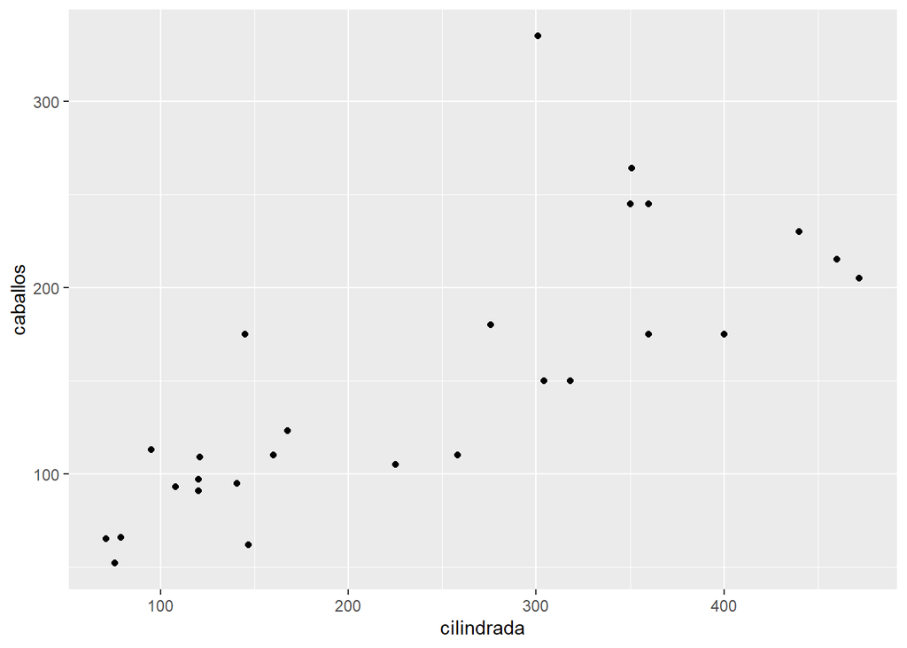

```r
ggplot(data = mtautos) +geom_point(mapping = aes(x = cilindrada, y = caballos))
```

Ahora podremos agregarle una “dimensión” en colores, estos serán la cantidad de cambios que tienen en su caja de cambios.

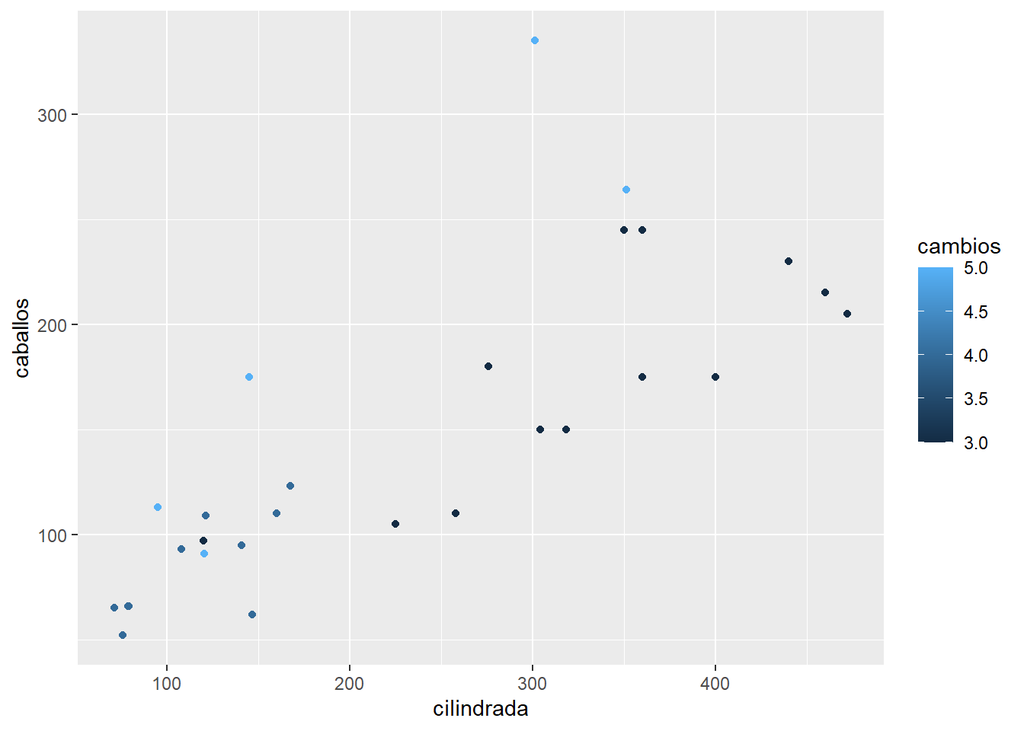

```r
ggplot(data = mtautos) + geom_point(mapping = aes(x = cilindrada, y = caballos, color = cambios))
```

Tambien podemos graficar en varias gráficas, filtrando por la caracteristica de una columna, en este caso la misma columna cambios

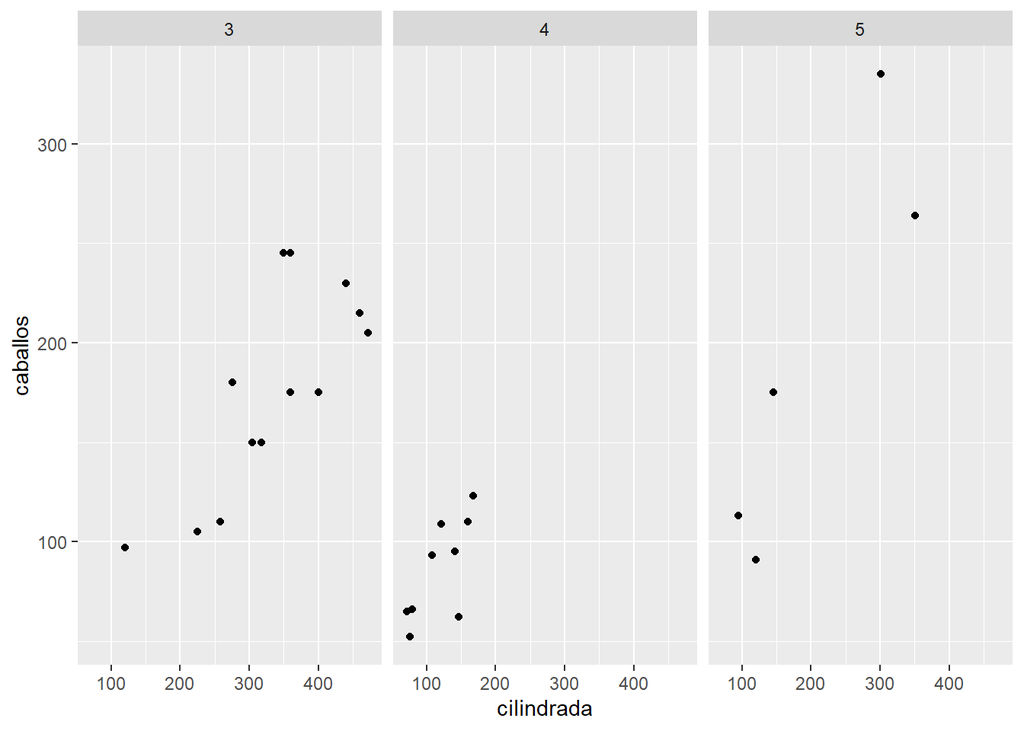

```r
ggplot(data = mtautos) + geom_point(mapping = aes(x = cilindrada, y = caballos)) + facet_wrap(~ cambios, nrow = 1)
```

### El segpundo tipo de gráfico: Forma geometrica

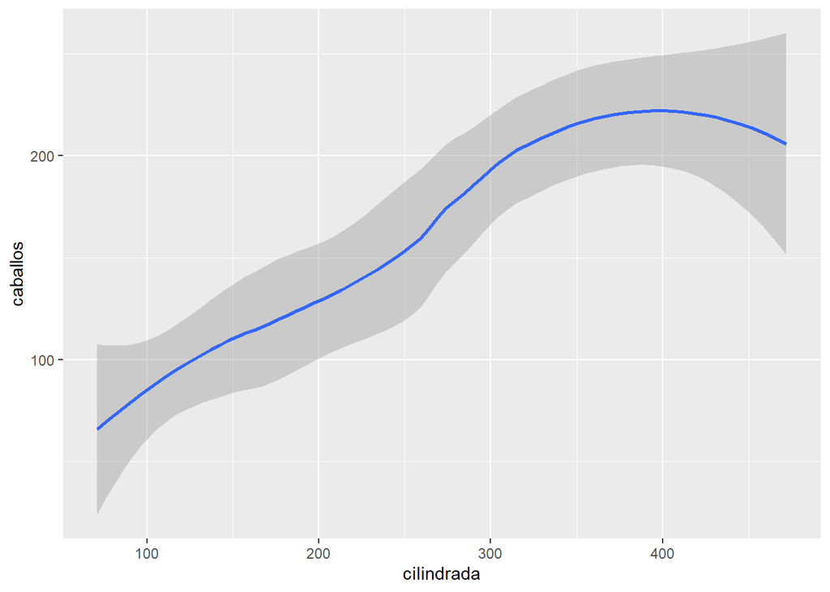

```r
#  línea suavizada ajustada a los datos
ggplot(data = mtautos) + geom_smooth(mapping = aes(x = cilindrada, y = caballos))
```

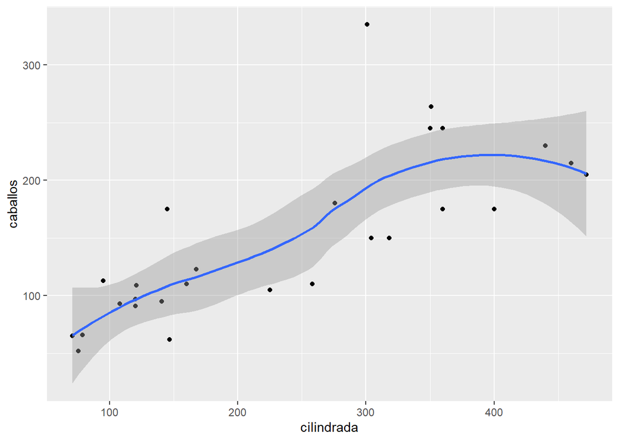

```r
#Tambien a ambas graficas al tiempo
ggplot(data = mtautos) + geom_point(mapping = aes(x = cilindrada, y = caballos)) + geom_smooth(mapping = aes(x = cilindrada, y = caballos))
```

### El tercer tipo de gráfico: Diagrama de barras

En este diagrama usamos un dataframe con datos de aviones, el cual nos muestra que la marca BOEING lidera el mercado de los aviones de aala fija multimotor.

El argumento ‘fill’ permite asignar un color a cada barra, hacendo referencial a la marca del avión.

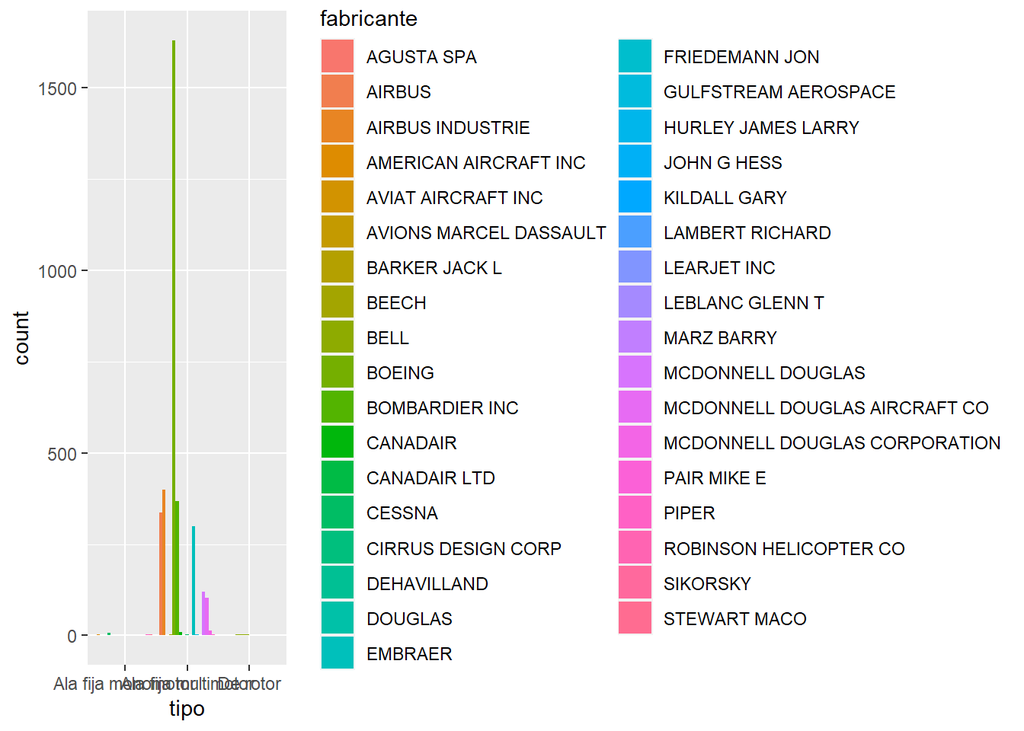

```r
ggplot(data = aviones) + geom_bar(mapping = aes(x = tipo, fill = fabricante),position = "dodge")
```

### El cuarto tipo de gráfico:

Conocido como diagrama de “bigotes”, Sus argumentos son:

- dataframe (aviones)

- Eje x ( años)
- Eje y (tipo de avion)
- la función geom_boxplot() permite convertir el ploteo en diagrama de cajas o bigotes
- La función coord_flip() voltea la orientación de la gráfica

se visualiza con la siguiente instrucción:

(Si desea rotarlo, elimine el # de la linea 301)

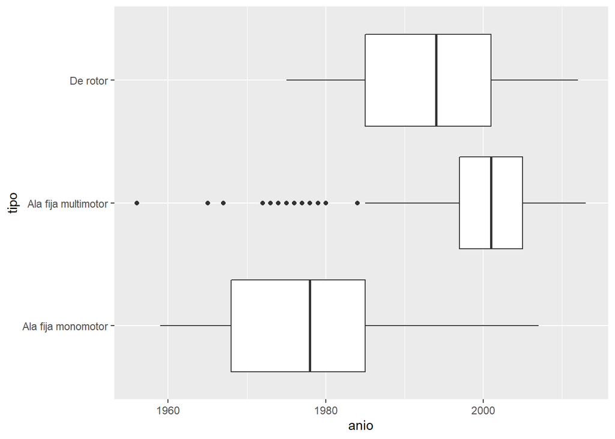

```r
ggplot(data = aviones, mapping = aes(x = anio, y = tipo)) + geom_boxplot() #+coord_flip()
```